# Ratios of Housing Units Affordable–and Affordable and Available–to Low-Income Households, by Income Thresholds and Tenure

Author

Will Curran-Groome

Published

Oct 2024

Abstract

This file produces two interrelated metrics describing housing affordability: 1) the ratio between housing units affordable at various income levels and the number of households at or below those income levels; and 2) the ratio between housing units affordable and available at various income levels and the number of households at or below those income levels.

## Overview

> “These [metrics] reflect the availability (or shortage) of housing affordable to households with low incomes. Housing is considered “affordable” when monthly costs fall at or below 30 percent of a household’s income. Affordability addresses whether a community’s housing stock would be sufficient if units were allocated solely to people that could afford them. A unit is affordable and available at a given income level if it (1) meets our definition of affordable for that income level and (2) is either vacant or occupied by a renter or owner with the same or a lower income. Income groups are defined for a family of four.” ([Source](https://upward-mobility.urban.org/sites/default/files/2024-09/Upward_Mobility_Data_Dashboard_Appendix.pdf))

First, we aim to describe the ratio of units that are affordable (i.e., cost less than or equal to 30% of household income) to the number of low-income households. We provide these estimates at three income thresholds: 30%, 50%, and 80% of the area median income (AMI), and subset by tenure.

This first metric is insightful but does not account for affordable units that are occupied by households above the low-income AMI thresholds; for example, a household earning 100% of AMI might be renting a housing unit that would be affordable to a household earning 80% of AMI. However, this unit is not meaningfully available to households earning 80% AMI because it’s already occupied. When this phenomenon exists at scale, a community’s stock of affordable housing–as measured in the first metric– may appear appropriate relative to its number of low-income households, but many of these low-income household may be unable to access this affordable housing due to competition from relatively higher-income households.

Our second metric accounts for this dynamic and measures the ratio of units that are affordable and available to the number of low-income households. We provide these estimates at the same income thresholds (30%, 50%, and 80% of AMI), and subset by tenure.

Below is an example of the structure of the data we will produce. Note that the final data also includes quality indicators for each of the metrics (not shown here). This script is used to produce both county- and place-level estimates, though it must be re-run to generate estimates for each geography.

| year | state | county | subgroup | subgroup_type | ratio_affordable_30ami | ratio_affordable_50ami | ratio_affordable_80ami | ratio_affordable_available_30ami | ratio_affordable_available_50ami | ratio_affordable_available_80ami |
| --- | --- | --- | --- | --- | --- | --- | --- | --- | --- | --- |
| 2022 | 01 | 01000 | tenure | owner | 0.5 | 0.6 | 0.7 | 0.4 | 0.5 | 0.6 |

### Analysis notes

- Unlike some other scripts and metrics in the Upward Mobility Metrics repository, this script produces two metrics. This is because these metrics, and the underlying data used to generate them, are closely interrelated. This script also produces estimates at two geographies (the place and county levels). To specify the intended geography, users need only change the `geography` variable in the first code chunk under the header “Housekeeping”.
- This analysis relies on 1-year American Community Survey (ACS) microdata from IPUMS. These data are used to generate estimates of housing units and households by income at the Public Use Microdata Area (PUMA) geography. We then attribute PUMA-level estimates to our geography of interest (either places or counties).
- Some of the key features of this analysis include:
  - Microdata are provided for occupied and vacant housing units separately, so we need to submit two queries for microdata from IPUMS. Microdata are queried, pre-processed, and written out to the `02_housing/data/temp` subfolder via the `` 02_housing/0``_get_housing_microdata.R `` script.
  - Housing costs are captured under multiple variables in the microdata, and some housing costs are not itemized in the microdata. Further, housing cost-related variables differ based on tenure. We standardize housing costs across vacant and occupied units and for rented and owned units so that we can compare annual housing costs to annual household incomes, which we benchmark against Department of Housing and Urban Development (HUD)-defined income thresholds.
  - These income thresholds are defined by HUD relative to the area median income (AMI). Generally, HUD calculates AMI thresholds at the county level, but in some states in New England, AMI thresholds vary at the sub-county level. We need to interpolate these AMI threshold to our geography of interest (either places or counties).
  - Our estimates of affordable and available units are by definition a subset of our estimate affordable units. That is to say: every affordable and available unit is affordable, but not every affordable unit is available.
  - Quality checks are consolidated in a single sub-section at the end of this file. Users should refer to comments in the code for clarity on programming decisions and other technical notes (e.g., descriptions relating to joins between datasets). Because joins are such a frequent source of error, every join in this script leverages the `tidylog` wrapper around `dplyr::left_join()`, which automatically generates output describing the join. If undesired, CTRL+F “tidylog::” and replace-all with ““.

### Analysis process

1. Import microdata, separately for vacant and occupied units
2. For vacant units:
   - For vacant units for sale, sum mortgage, taxes, and insurance estimates to produce a `total_monthly_cost` estimate
   - For vacant units for rent, adjust the existing monthly gross rent variable to account for inconsistencies in measurement of utilities and fuels costs as part of gross rent:
     - Using the occupied rental unit data, calculate average ratio of monthly cost vs advertised price of renting, i.e., `ratio = RENTGRS / RENT`, by place or county
     - Join these averages calculated above back to our vacant rental microdata and adjust `RENTGRS` such that `RENTGRS = RENT * ratio`. This improves the comparability of housing costs for vacant rental units to the housing costs of other housing units in our data
3. Import AMI levels for each Fair Market Rent (FMR) area (the geography at which FMRs are calculated)
   1. Where there are AMIs at the sub-county level, group by county and take the mean of the sub-county AMIs
   2. When producing place-level estimates, interpolate county-level AMIs to the place level using a county-place, population-weighted crosswalk
4. Generate AMI-based indicators for our vacant and occupied microdata that capture whether each household or housing unit is affordable and, separately, available at each of our three AMI thresholds
5. Summarize by county/place and combine the two datasets so that we have a single dataset with counts of households/units by affordability/availability
6. Create data quality flags, apply data suppression for geographies with unreliable data, and clean and restructure the data into its final form
7. Conduct quality checks

## Housekeeping

```r
# Libraries you'll need
library(tidyverse)
library(ipumsr)
library(readxl)
library(here)
library(urbnthemes)
library(openxlsx)
options(scipen = 99999) ## no scientific notation

# county_years = c(2014:2019, 2021:2022) ## 2023 not yet released via IPUMS
# place_years = c(2014:2019, 2021:2022) ## 2023 not yet released via IPUMS

place_years = c(2021, 2022)
county_years = c(2021, 2022)

source(here("functions", "testing", "evaluate_final_data.R"))

# If input data files have not already been generated,
# source and execute the script that does this
if (!file.exists(here("02_housing", "data", "temp", "crosswalked_pumas_place_2022.csv"))) {
  source(here("02_housing", "0_get_housing_microdata.R"))
  get_housing_microdata(
    county_years = county_years,
    place_years = place_years)
}

geography = "county"
temporary_data_path <- here("02_housing", "data", "temp")
```

## Import microdata

- Combine data across years
- Filter to only include “households”–i.e., where `GQ` values are less than 3–and to exclude various types of group quarters, which do not comprise part of the typical housing market
- Filter to retain only a single record per household–i.e., where `PERNUM == 1`–to avoid double-counting households

For more information: https://usa.ipums.org/usa-action/variables/GQ#codes_section

```r
housing_microdata <- bind_rows(
  read_csv(here(temporary_data_path, paste0(geography, "_prepared_microdata_2022.csv"))) %>%
    mutate(
      year = 2022,
      crosswalk_period = as.character(crosswalk_period)),
  read_csv(here(temporary_data_path, paste0(geography, "_prepared_microdata_2021.csv"))) %>%
    mutate(
      year = 2021,
      crosswalk_period = as.character(crosswalk_period))) %>%
  filter(
    PERNUM == 1,
    GQ < 3) %>%
  ## dropping columns we don't use in this analysis
  select(-c(PERWT, EDUC, EDUCD, GRADEATT, EMPSTAT, AGE))
```

The housing microdata does not include vacant units, which we query separately from the IPUMS API. Here, we prepare the vacant unit-specific microdata. Later, we will combine vacant units with occupied units to produce estimates of the whole housing stock.

- Filter to only include units that are vacant for rent, vacant for sale, or rented/sold but not yet occupied (`VACANCY %in% c(1:3)`) – these are the units that are part of the conventional housing market.
- Derive an estimate of total monthly housing costs for each vacant unit, incorporating mortgage costs, insurance costs, and property taxes.

Note: `ADJUST` standardizes income variables within a calendar year. See here for more information: https://usa.ipums.org/usa/acsincadj.shtml.

```r
vacancy_microdata <- bind_rows(
    read_csv(here(temporary_data_path, "vacancy_microdata_2022.csv")),
    read_csv(here(temporary_data_path, "vacancy_microdata_2021.csv"))) %>%
  filter(
    VACANCY %in% c(
      1, # for rent
      2, # for sale
      3)) %>% # renter or sold but not yet occupied
  # Convert 9999999 to NA and then multiply by ADJUST for all non-missing observations
  mutate(
    year = YEAR,
    VALUEH = if_else(VALUEH == 9999999, NA,  VALUEH * ADJUST),
    loan_amount = 0.9 * VALUEH,
    monthly_mortgage_cost = .005, # monthly interest
    # this calculates monthly compounding interest on a 30-year fixed-rate mortgage
    monthly_principal_interest_cost = loan_amount * monthly_mortgage_cost *
      ((1 + monthly_mortgage_cost) ** 360) / (((1 + monthly_mortgage_cost) ** 360) - 1),
    # typical annual private mortgage insurance is .007 of loan amount per year
    monthly_private_mortgage_insurance_cost = (.007 * loan_amount) / 12,
    # taxes assumed to be 25% of monthly principal and interest
    monthly_taxes_cost = .25 * monthly_principal_interest_cost,
    monthly_cost_total = monthly_principal_interest_cost +
      monthly_private_mortgage_insurance_cost + monthly_taxes_cost) %>%
  # drop unneeded columns
  select(year, puma, statefip, HHWT, ADJUST, RENT, RENTGRS, VALUEH, monthly_cost_total)
```

`RENTGRS` provides a more comparable estimate of total rental costs than does `RENT`, which may or may not include utilities and fuels. While `RENTGRS` is available for rented units, it is not available for vacant units. To improve the comparability of rental costs for vacant units, we:

- Calculate the ratio between `RENTGRS` and `RENT` for each rented unit
- Group by state, geography (county/place), and year, and calculate a weighted average of this `RENTGRS`/`RENT` ratio (weighted by our `HHWT` variable)
- In a following step, we join these weighted averages back to our vacant unit data and use them to adjust the `RENT` variable

For more information see: https://usa.ipums.org/usa-action/variables/RENTGRS#description_section

```r
# Import crosswalks to merge PUMAs to places and counties
crosswalk_path = if_else(
  geography == "place",
  here("geographic-crosswalks", "data", "crosswalk_puma_to_place.csv"),
  here("geographic-crosswalks", "data", "crosswalk_puma_to_county.csv"))

puma_crosswalk <- read_csv(crosswalk_path) %>%
  # recode to match 2021 data
  mutate(
    crosswalk_period = if_else(
      crosswalk_period == "pre-2022", "2021", crosswalk_period) %>% as.numeric(),
    GEOID = str_c(statefip, .data[[geography]])) %>%
  # omitting Puerto Rico PUMAs, for which we do not calculate estimates
  filter(statefip != 72)

# Calculate RENTGRS/RENT ratios and associated weighted means by geography for
# occupied units
rent_ratio <- housing_microdata %>%
  # Keep only renter households
  filter(OWNERSHP == 2) %>%
  mutate(ratio_rentgrs_rent = RENTGRS / RENT) %>%
  # Calculate weighted mean ratio by geography x year - values are multiplied by
  # afact in 0_housing_microdata.qmd so summarizing gets the place- or county-level value
  group_by(statefip, .data[[geography]], year) %>%
  summarize(
    weighted_mean_ratio_rentgrs_rent = weighted.mean(
      ratio_rentgrs_rent, w = HHWT, na.rm = TRUE))

# join places/counties to pumas using the crosswalk
## county-level join summaries - 2021:2022
  # all rows in the vacancy microdata join to the puma crosswalk
  # 32 rows in the crosswalk do not join to the microdata
  #   (PUMA-years without vacant units, not an issue)
  # all rows in the joint data join to the rent ratio data
  # 2 rows in the rent_ratio data do not join to the joint data
  #   (these don't have any vacant units, not an issue)
## place-level join summaries - 2021:2022
  #
vacant_crosswalk <- tidylog::left_join(
    vacancy_microdata,
    puma_crosswalk,
    by = c("statefip", "puma", "year" = "crosswalk_period"),
    relationship = "many-to-many") %>%
  mutate(GEOID = str_c(statefip, .data[[geography]])) %>%
  # limit only to places/counties of interest
  filter(GEOID %in% puma_crosswalk$GEOID) %>%
  tidylog::left_join(rent_ratio, by = c("statefip", geography, "year")) %>%
  mutate(RENTGRS = RENT * weighted_mean_ratio_rentgrs_rent)
```

### Import AMI data

HUD publishes annual AMI levels and associated thresholds for 30%, 50%, and 80% of AMI. These levels are available for “Fair Market Rent” (FMR) geographies, which are typically but not always counties.

In this section, we:

- Import the AMI data from HUD
- Crosswalk the AMI thresholds to our geographies of interest

```r
# Access via https://www.huduser.gov/portal/datasets/il.html#data_2022
urls_fmr_income_limits <- c(
  "https://www.huduser.gov/portal/datasets/il/il14/Poverty.xls",
  "https://www.huduser.gov/portal/datasets/il/il15/Section8_Rev.xlsx",
  "https://www.huduser.gov/portal/datasets/il/il16/Section8-FY16.xlsx",
  "https://www.huduser.gov/portal/datasets/il/il17/Section8-FY17.xlsx",
  "https://www.huduser.gov/portal/datasets/il/il18/Section8-FY18.xlsx",
  "https://www.huduser.gov/portal/datasets/il/il19/Section8-FY19.xlsx",
# "https://www.huduser.gov/portal/datasets/il/il21/Section8-FY20.xlsx",
  "https://www.huduser.gov/portal/datasets/il/il21/Section8-FY21.xlsx",
  "https://www.huduser.gov/portal/datasets/il/il22/Section8-FY22.xlsx")

download_hud_income_limits <- function(year, url) {
  filename = str_split(url, "/") %>% .[[1]] %>% .[[length(.)]]
  download.file(url = url, destfile = here(temporary_data_path, filename), mode = "wb")

  # Import the data file as a dataframe
  fmr_income_limits <- readxl::read_excel(path = here(temporary_data_path, filename)) %>%
    janitor::clean_names() %>%
    transmute(
      year = year,
      fips = fips2010,
      across(
        .cols = c(state, county),
        .fns = as.character),
      state = str_pad(state, side = "left", width = 2, pad = "0"),
      county = str_pad(county, side = "left", width = 3, pad = "0"),
      sub_county = str_sub(fips, 6, 10) %>% if_else(. == "99999", NA, .),
      # _4 denotes the level applies to a four-person household
      # ELI_4 is 30% of median rent: Extremely low-income
      # l50_4 is 50% of median rent: Very low-income
      # l80_4 is 80% of median rent: Low-income
      level_30ami = eli_4,
      level_50ami = l50_4,
      level_80ami = l80_4)

  return(fmr_income_limits)
}

# download and combine income limits data into one file
fmr_income_limits <- map2_dfr(
    county_years, urls_fmr_income_limits[7:8],
    download_hud_income_limits) %>%
  filter(year %in% c(county_years, place_years))
```

Income limits are specified at one of two geographies: the county (mostly), or the sub-county (in some areas in New England). We need to translate the income limits to our geography of interest (either the county-level or the place-level). We do this as follows:

- We aggregate our income limits to the county level. For most counties, this doesn’t require any work, because there’s only a single income limit for the county. For counties with sub-county-level income limits, we take the mean of these limits.
- For the case where we’re producing place-level estimates, we then interpolate the county-level income limits to the place level, weighting by population.

```r
county_income_limits = fmr_income_limits %>%
  group_by(year, state, county) %>%
  summarize(
    across(
      .cols = matches("ami"),
      .fns = mean)) %>%
  ungroup()

if (geography == "place") {
  county_place_crosswalk <- read_csv(
      here("geographic-crosswalks", "data", "geocorr2022_county_place.csv")) %>%
    mutate(
      state = str_pad(as.numeric(state), side = "left", width = 2, pad = "0"),
      place = str_pad(as.numeric(place), side = "left", width = 5, pad = "0"))

  place_income_limits = county_income_limits %>%
    tidylog::left_join(county_place_crosswalk, by = c("state", "county")) %>%
    group_by(state, place, year) %>%
    summarize(
      across(
        .cols = matches("ami"),
        .fns = ~ weighted.mean(x = .x, na.rm = TRUE, w = pop20))) %>%
    ungroup()

  crosswalked_income_limits1 = place_income_limits
} else { crosswalked_income_limits1 = county_income_limits }

geography_pad_width = if_else(geography == "place", 5, 3)

crosswalked_income_limits2 = crosswalked_income_limits1 %>%
  transmute(
    GEOID = str_c(state, .data[[geography]]),
    statefip = state,
    "{geography}" := str_pad(
      as.numeric(.data[[geography]]), side = "left", width = geography_pad_width, pad = "0"),
    year,
    across(.cols = matches("ami")))

## in 2017, Valdez-Cordova Census Area -- a county-equivalent geography -- is abolished
## and is replaced by Chugach Census Area and Copper River Census Area, both of which
## are also county-equivalent geographies. While Valdez-Cordova is listed in the HUD
## AMI limits data, our ACS microdata are crosswalked to the current Census Areas.
## Accordingly, we adjust our income limits data such that the AMI thresholds for
## Valdez-Cordova are associated both with Chugach and Copper River Census Areas.

crosswalked_income_limits3 = tibble(
  county_current = c("063", "066"),
  county_old = c("261")) %>%
  left_join(
    crosswalked_income_limits2 %>%
      filter(statefip == "02"),
    by = c("county_old" = "county"),
    relationship = "many-to-many") %>%
  select(-county_old) %>%
  rename(county = county_current) %>%
  mutate(GEOID = str_c(statefip, county))

crosswalked_income_limits = crosswalked_income_limits2 %>%
  filter(!(statefip == "02" & county == "261")) %>%
  bind_rows(crosswalked_income_limits3) %>%
  filter(GEOID %in% puma_crosswalk$GEOID)
```

## Generate AMI indicators

Here we calculate which units are affordable for a family of four at 80%, 50%, and 30% of AMI (regardless of the actual unit size). We also create variables for total population at 80% AMI, 50% AMI, and 30% AMI, including breakdowns for renter and owner subgroups. “Affordable” means costs are <= 30% of the household’s income. For owners, we use the housing cost, and for renters, we use the gross rent.

```r
## these are data on occupied housing units
## county-level join summaries - 2021:2022
  # 0 rows only in housing_microdata
  # 0 rows only in crosswalked_income_limits
household_affordability <- tidylog::left_join(
    housing_microdata,
    crosswalked_income_limits,
    by = c("statefip", geography, "year"),
    relationship = "many-to-one") %>%
  mutate(
    ## all households below ami levels
    across(
      .cols = matches("ami$"),
      # Note: I (Will) have changed this logic to be inclusive of the AMI threshold;
      # previously, I think such values would have defaulted to NAs (an error)
      .fns = ~ if_else(HHINCOME <= .x, 1, 0),
      .names = "all_below_{.col %>% stringr::str_extract('[0-9]{2}ami')}"),
    ## renters below ami levels
    across(
      .cols = c(all_below_80ami, all_below_50ami, all_below_30ami),
      .fns = ~ if_else(.x == 1 & OWNERSHP == 2, 1, 0),
      .names = "renter_{.col %>% stringr::str_remove('all_')}"),
    ## owners below ami levels
    across(
      .cols = c(all_below_80ami, all_below_50ami, all_below_30ami),
      .fns = ~ if_else(.x == 1 & OWNERSHP == 1, 1, 0),
      .names = "owner_{.col %>% stringr::str_remove('all_')}"),
    ## this standardized cost variable simplifies subsequent calculations
    applicable_housing_cost = if_else(OWNERSHP == 2, RENTGRS, OWNCOST),
    ## renter households with affordable housing costs
    across(
      .cols = c(level_30ami, level_50ami, level_80ami),
      .fns = ~ if_else(OWNERSHP == 2 & applicable_housing_cost * 12 <= .x * .3, 1, 0),
      .names = "renter_affordable_{.col}"),
    ## owner households with affordable housing costs
    across(
      .cols = c(level_30ami, level_50ami, level_80ami),
      .fns = ~ if_else(OWNERSHP == 1 & applicable_housing_cost * 12 <= .x * .3, 1, 0),
      .names = "owner_affordable_{.col}"),
    ## any households with affordable housing costs
    across(
      .cols = c(level_30ami, level_50ami, level_80ami),
      .fns = ~ if_else(applicable_housing_cost * 12 <= .x * .3, 1, 0),
      .names = "all_affordable_{.col}"),
    ## calculating affordable and available across all subgroups (and overall)
    across(
      .cols = matches("affordable"), # e.g., all_affordable_level_80ami
      # if the unit is affordable at the given AMI level and is occupied by a household
      # at or below that AMI level
      .fns = ~ if_else(
        .x == 1 & get(str_replace(cur_column(), "affordable_level", "below")) == 1, 1, 0),
      .names = "{.col %>% stringr::str_replace('affordable', 'available')}"))

## these are data on vacant housing units
## county-level join summaries - 2021:2022
  # 0 rows only in vacant_microdata
  # 2 rows only in crosswalked_income_limits -- these areas don't have any vacant
  #   units (no issue)
vacant_affordability <- tidylog::left_join(
    vacant_crosswalk,
    crosswalked_income_limits,
    by = c("statefip", geography, "year"),
    relationship = "many-to-one") %>%
  mutate(
    ## binary indicators
    ## for rental units, if adjusted annual rent is less than or equal to the given
      ## AMI level
    ## for ownership units, if estimated annual housing cost is less than or equal
      ## to the given AMI level for all units
    across(
      .cols = c(level_30ami, level_50ami, level_80ami),
      .fns = ~ case_when(
        is.na(.x) ~ NA,
        RENTGRS > 0 ~ (RENTGRS * 12) <= (.x * .3),
        !is.na(VALUEH) ~ (monthly_cost_total * 12) <= (.x * .3),
        is.na(VALUEH) ~ NA),
      .names = "all_affordable_{.col}"),
    across(
      .cols = c(level_30ami, level_50ami, level_80ami),
      .fns = ~ case_when(
        is.na(.x) ~ NA,
        RENTGRS > 0 ~ (RENTGRS * 12) <= (.x * .3)),
      .names = "renter_affordable_{.col}"),
    across(
      .cols = c(level_30ami, level_50ami, level_80ami),
      .fns = ~ case_when(
        is.na(.x) ~ NA,
        !is.na(VALUEH) ~ (monthly_cost_total * 12) <= (.x * .3),
        is.na(VALUEH) ~ NA),
      .names = "owner_affordable_{.col}"),
    # convert booleans to integers
    across(matches("affordable"), ~ as.integer(.x)))
```

## Aggregate and calculate metrics

```r
household_affordability_summed <- household_affordability %>%
  group_by(statefip, .data[[geography]], year) %>%
  summarize(
    # get unweighted counts for quality flags, adjusting for spatial interpolation using afact
    across(
      .cols = matches("below"),
      .fns = ~ sum(.x * afact),
      .names = "{.col}_quality"),
    # get weighted counts for actual statistics/estimates
    across(
      .cols = c(matches("below|affordable|available"), -matches("quality")),
      .fns = ~ sum(.x * HHWT, na.rm = TRUE))) %>%
  ungroup() %>%
  rename("state" = "statefip")

vacant_affordability_summed <- vacant_affordability %>%
  group_by(statefip, .data[[geography]], year) %>%
  summarize(
    across(
      .cols = matches("affordable"),
      .fns = ~ sum(.x * HHWT, na.rm = TRUE),
      .names = "{.col}_vacant")) %>%
  ungroup() %>%
  rename("state" = "statefip")

## here we (finally) combine our occupied and vacant data
## county-level join summaries - 2021:2022
  # 2 rows only in household_affordability_summed -- these areas don't have any
  #   vacant units (no issue)
  # 0 rows only in vacant_affordability_summed
housing_summed <- tidylog::left_join(
    household_affordability_summed,
    vacant_affordability_summed,
    by = c("state", geography, "year"),
    relationship = "one-to-one") %>%
  ungroup() %>%
  mutate(
    ## share affordable and available
    across(
      .cols = matches("available"),
      # available and affordable occupied units + all vacant units (by definition
      # available) / all affordable units
      .fns = ~ (
        .x + ## available, occupied units
        ## vacant units
        get(str_c(cur_column() %>% str_replace("available", "affordable"), "_vacant"))) /
        ## households at or below income level
        get(str_replace(cur_column(), "available_level", "below")),
      .names = "share_{.col}"),
    ## all households
    ## the sum of housing units -- both vacant and occupied -- that are affordable
    ## at a given AMI level divided by the number of households below that AMI level
    across(
      .cols = c(matches("below"), -matches("quality")),
      .fns = ~
        (get(str_c(str_replace(cur_column(), "below", "affordable_level"))) +
        get(str_c(str_replace(cur_column(), "below", "affordable_level"), "_vacant"))) / .x,
      .names = "share_{.col %>% stringr::str_replace('below', 'affordable_level')}"))
```

## Finalize and export data

If the unweighted sum of interpolated households (reflected in `afact`) is under 30, we suppress that cell because it is likely to be highly unreliable.

```r
# read in the puma interpolation quality files
puma_interpolation_quality <- bind_rows(
  read_csv(here(
    temporary_data_path, paste0("crosswalked_pumas_quality_", geography, "_2021.csv"))) %>%
    mutate(year = 2021),
  read_csv(here(
    temporary_data_path, paste0("crosswalked_pumas_quality_", geography, "_2022.csv"))) %>%
    mutate(year = 2022)) %>%
  rename("state" = "statefip")

## county-level join summaries - 2021:2022
  # 0 rows only in housing_summed
  # 0 rows only in puma_interpolation_quality
housing_summed_quality =  tidylog::left_join(
    housing_summed,
    puma_interpolation_quality,
    by = c("state", geography, "year"),
    relationship = "one-to-one") %>%
  mutate(
    across(
      .cols = matches("quality"),
      .fns = ~ if_else(.x < 30, 1, 0)),
    across(
      .cols = matches("quality"),
      .fns = ~ if_else(.x == 1, NA, puma_flag)))

# turn long for subgroup output
housing_subgroups <- housing_summed_quality %>%
  select(state, !!geography, year, matches("share|quality")) %>%
  ## rename columns to facilitate re-structuring
  rename_with(
    .cols = matches("quality"),
    .fn = ~ .x %>% str_remove("_quality") %>%
      str_replace("below", "affordable_quality_level") %>% str_c("share_", .)) %>%
  ## the quality values are the same for available and affordable, but we duplicate them
  ## (with different column names) for the available estimates, for consistency
  mutate(
    across(
      .cols = matches("quality"),
      .fns = ~ .x,
      .names = "{.col %>% stringr::str_replace('affordable', 'available')}")) %>%
  ## restructure so that each row is a geography x year x subgroup combination
  pivot_longer(
    cols = matches("share_"),
    names_to = c("subgroup", "measure_type", "ami"),
    names_pattern = "share_(all|renter|owner)_(affordable_|affordable_quality_|available_|available_quality_)level_([0-9]{2}ami)",
    values_to = "value") %>%
  pivot_wider(
    names_from = c(measure_type, ami),
    names_sep = "",
    values_from = value) %>%
  rename_with(
    .cols = matches("affordable|available"),
    .fn = ~ str_c("ratio_", .x)) %>%
  mutate(
    subgroup_type = "tenure",
    subgroup = subgroup %>% str_to_sentence,
    # suppress areas with insufficient sample sizes
    across(
      .cols = c(matches("ratio"), -matches("quality")),
      .fns = ~ if_else(
        is.na(get(cur_column() %>% str_replace_all(
          c("affordable" = "affordable_quality", "available" = "available_quality")))),
        NA,
        .x))) %>%
  rename_with(
    .cols = matches("quality"),
    .fn = ~ str_remove(.x, "quality_") %>% str_c(., "_quality")) %>%
  select(year, state, !!geography, subgroup_type, subgroup, matches("ratio")) %>%
  arrange(state, .data[[geography]], subgroup, desc(year))

housing_overall <- housing_subgroups %>%
  filter(subgroup == "All")

# export our files as .CSVs
write_csv(
  housing_overall, here("02_housing", "data", str_c("housing_", geography, ".csv")))
write_csv(
  housing_subgroups, here("02_housing", "data", str_c("housing_", geography, "_subgroups.csv")))
```

## Quality checks

The final dataset, including all subgroups, meets all the assertions contained in `evaluate_final_data.R`.

```r
evaluate_final_data(
  exp_form_path = here(
    "02_housing", "housing_affordability_tenure_final_data_evaluation_form.csv"),
  data = housing_subgroups,
  geography = geography,
  subgroups = TRUE,
  confidence_intervals = FALSE)
```

```
[1] "This data passes all tests!"
```

Both metrics are ratios and cannot be negative. We extend the assumption and assert that no ratios are equal to zero, which mathematically is feasible but practically is highly unlikely.

```r
stopifnot(
  housing_overall %>%
    filter(if_any(.cols = c(matches("ratio"), -matches("quality")), .fns = ~ .x <= 0)) %>%
    nrow() == 0)
```

Affordable-and-available ratios by definition must be equal to or lesser than the corresponding affordable ratio.

```r
stopifnot(
  housing_overall %>%
    select(-matches("quality")) %>%
    mutate(
      across(
        .cols = c(matches("ratio_affordable"), ),
        .fns = ~ .x - get(str_replace(cur_column(), "affordable", "available")),
        .names = "{.col}_difference")) %>%
    arrange(ratio_affordable_80ami_difference) %>%
    filter(if_any(.cols = matches("difference"), .fns = ~ .x < 0)) %>%
    nrow() == 0)
```

For both affordability and availability, distributions for renters should be more right-skewed (i.e., peaking/clustered at smaller values of X) than for owners.

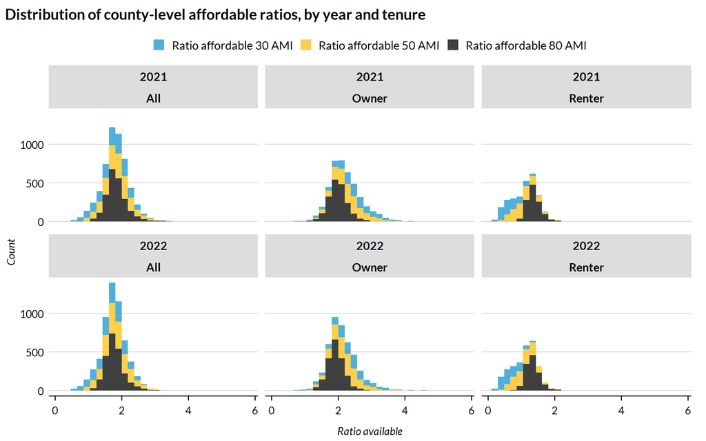

```r
housing_subgroups %>%
  select(-matches("quality")) %>%
  rename_with(
    .cols = matches("ratio"),
    .fn = ~ str_replace_all(.x, c("_" = " ", "ami" = " ami")) %>% str_to_sentence %>%
      str_replace("ami", "AMI")) %>%
  pivot_longer(
    cols = matches("Ratio affordable")) %>%
  filter(!is.na(value)) %>%
  ggplot() +
    geom_histogram(aes(x = value, fill = name), alpha = .75) +
  facet_wrap(~ year + subgroup) +
  labs(
    x = "Ratio available",
    y = "Count",
    title = paste0(
      "Distribution of ", geography, "-level affordable ratios, by year and tenure")) +
  urbnthemes::theme_urbn_print()
```

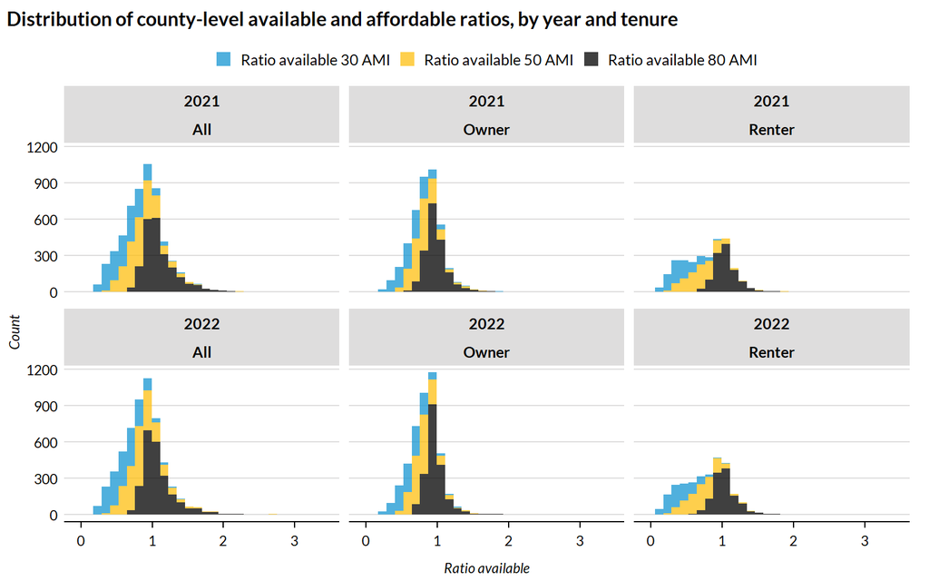

```r
housing_subgroups %>%
  select(-matches("quality")) %>%
  rename_with(
    .cols = matches("ratio"),
    .fn = ~ str_replace_all(.x, c("_" = " ", "ami" = " ami")) %>% str_to_sentence %>%
      str_replace("ami", "AMI")) %>%
  pivot_longer(
    cols = matches("Ratio available")) %>%
  filter(!is.na(value)) %>%
  ggplot() +
    geom_histogram(aes(x = value, fill = name), alpha = .75) +
  facet_wrap(~ year + subgroup) +
  labs(
    x = "Ratio available",
    y = "Count",
    title = paste0(
      "Distribution of ", geography,
      "-level available and affordable ratios, by year and tenure")) +
  urbnthemes::theme_urbn_print()
```

```r
housing_subgroups %>%
  select(year, subgroup, c(matches("ratio"), -matches("quality"))) %>%
  group_by(year, subgroup) %>%
  skimr::skim() %>%
  arrange(desc(year)) %>%
  as_tibble() %>%
  mutate(
    across(
      .cols = c(matches("numeric"), -matches("hist")),
      .fns = ~ round(.x, digits = 2))) %>%
  knitr::kable()
```

| skim_type | skim_variable | year | subgroup | n_missing | complete_rate | numeric.mean | numeric.sd | numeric.p0 | numeric.p25 | numeric.p50 | numeric.p75 | numeric.p100 | numeric.hist |
| --- | --- | --- | --- | --- | --- | --- | --- | --- | --- | --- | --- | --- | --- |
| numeric | ratio_available_30ami | 2022 | All | 1569 | 0.5007954 | 0.62 | 0.22 | 0.15 | 0.45 | 0.61 | 0.76 | 1.61 | ▅▇▅▁▁ |
| numeric | ratio_available_30ami | 2022 | Owner | 2053 | 0.3468024 | 0.64 | 0.20 | 0.16 | 0.50 | 0.63 | 0.76 | 1.95 | ▃▇▁▁▁ |
| numeric | ratio_available_30ami | 2022 | Renter | 2434 | 0.2255807 | 0.42 | 0.18 | 0.07 | 0.28 | 0.39 | 0.54 | 1.17 | ▅▇▃▁▁ |
| numeric | ratio_available_50ami | 2022 | All | 1273 | 0.5949730 | 0.84 | 0.23 | 0.36 | 0.70 | 0.82 | 0.95 | 2.72 | ▇▆▁▁▁ |
| numeric | ratio_available_50ami | 2022 | Owner | 1702 | 0.4584792 | 0.80 | 0.16 | 0.41 | 0.69 | 0.79 | 0.87 | 2.14 | ▆▇▁▁▁ |
| numeric | ratio_available_50ami | 2022 | Renter | 2215 | 0.2952593 | 0.71 | 0.21 | 0.16 | 0.56 | 0.71 | 0.85 | 1.38 | ▁▆▇▃▁ |
| numeric | ratio_available_80ami | 2022 | All | 833 | 0.7349666 | 1.08 | 0.24 | 0.67 | 0.94 | 1.02 | 1.16 | 2.73 | ▇▃▁▁▁ |
| numeric | ratio_available_80ami | 2022 | Owner | 1183 | 0.6236080 | 0.97 | 0.15 | 0.66 | 0.89 | 0.95 | 1.02 | 2.77 | ▇▁▁▁▁ |
| numeric | ratio_available_80ami | 2022 | Renter | 1938 | 0.3833917 | 1.04 | 0.18 | 0.53 | 0.93 | 1.01 | 1.11 | 2.17 | ▁▇▂▁▁ |
| numeric | ratio_affordable_30ami | 2022 | All | 1569 | 0.5007954 | 1.65 | 0.46 | 0.52 | 1.36 | 1.70 | 1.97 | 3.24 | ▂▆▇▂▁ |
| numeric | ratio_affordable_30ami | 2022 | Owner | 2053 | 0.3468024 | 2.33 | 0.59 | 0.53 | 1.98 | 2.34 | 2.66 | 5.67 | ▁▇▃▁▁ |
| numeric | ratio_affordable_30ami | 2022 | Renter | 2434 | 0.2255807 | 0.67 | 0.27 | 0.19 | 0.46 | 0.63 | 0.86 | 1.47 | ▆▇▅▃▁ |
| numeric | ratio_affordable_50ami | 2022 | All | 1273 | 0.5949730 | 1.81 | 0.39 | 0.84 | 1.57 | 1.80 | 2.06 | 3.75 | ▂▇▃▁▁ |
| numeric | ratio_affordable_50ami | 2022 | Owner | 1702 | 0.4584792 | 2.23 | 0.40 | 1.21 | 1.96 | 2.22 | 2.47 | 3.75 | ▂▇▇▂▁ |
| numeric | ratio_affordable_50ami | 2022 | Renter | 2215 | 0.2952593 | 1.07 | 0.31 | 0.26 | 0.84 | 1.06 | 1.29 | 2.18 | ▂▇▇▂▁ |
| numeric | ratio_affordable_80ami | 2022 | All | 833 | 0.7349666 | 1.79 | 0.29 | 1.08 | 1.61 | 1.75 | 1.93 | 3.52 | ▂▇▂▁▁ |
| numeric | ratio_affordable_80ami | 2022 | Owner | 1183 | 0.6236080 | 1.93 | 0.25 | 1.20 | 1.77 | 1.92 | 2.08 | 3.77 | ▂▇▁▁▁ |
| numeric | ratio_affordable_80ami | 2022 | Renter | 1938 | 0.3833917 | 1.33 | 0.21 | 0.63 | 1.19 | 1.31 | 1.44 | 2.45 | ▁▇▅▁▁ |
| numeric | ratio_available_30ami | 2021 | All | 1592 | 0.4934776 | 0.65 | 0.24 | 0.13 | 0.47 | 0.64 | 0.80 | 2.24 | ▆▇▁▁▁ |
| numeric | ratio_available_30ami | 2021 | Owner | 2088 | 0.3356666 | 0.67 | 0.22 | 0.16 | 0.51 | 0.67 | 0.79 | 2.10 | ▃▇▁▁▁ |
| numeric | ratio_available_30ami | 2021 | Renter | 2430 | 0.2268533 | 0.43 | 0.19 | 0.05 | 0.29 | 0.40 | 0.55 | 1.12 | ▃▇▅▂▁ |
| numeric | ratio_available_50ami | 2021 | All | 1347 | 0.5714286 | 0.85 | 0.26 | 0.32 | 0.69 | 0.82 | 0.96 | 3.38 | ▇▃▁▁▁ |
| numeric | ratio_available_50ami | 2021 | Owner | 1790 | 0.4304804 | 0.80 | 0.18 | 0.24 | 0.68 | 0.79 | 0.88 | 2.25 | ▂▇▁▁▁ |
| numeric | ratio_available_50ami | 2021 | Renter | 2264 | 0.2796691 | 0.70 | 0.22 | 0.18 | 0.55 | 0.69 | 0.84 | 2.02 | ▃▇▂▁▁ |
| numeric | ratio_available_80ami | 2021 | All | 871 | 0.7228762 | 1.10 | 0.25 | 0.55 | 0.95 | 1.04 | 1.20 | 3.45 | ▇▃▁▁▁ |
| numeric | ratio_available_80ami | 2021 | Owner | 1252 | 0.6016545 | 0.98 | 0.18 | 0.57 | 0.89 | 0.96 | 1.05 | 3.06 | ▇▂▁▁▁ |
| numeric | ratio_available_80ami | 2021 | Renter | 1968 | 0.3738466 | 1.05 | 0.17 | 0.50 | 0.95 | 1.03 | 1.12 | 2.20 | ▁▇▂▁▁ |
| numeric | ratio_affordable_30ami | 2021 | All | 1592 | 0.4934776 | 1.73 | 0.49 | 0.43 | 1.40 | 1.76 | 2.06 | 3.54 | ▂▆▇▂▁ |
| numeric | ratio_affordable_30ami | 2021 | Owner | 2088 | 0.3356666 | 2.45 | 0.61 | 0.56 | 2.09 | 2.44 | 2.79 | 5.36 | ▁▇▇▁▁ |
| numeric | ratio_affordable_30ami | 2021 | Renter | 2430 | 0.2268533 | 0.69 | 0.29 | 0.16 | 0.46 | 0.64 | 0.88 | 1.65 | ▅▇▅▂▁ |
| numeric | ratio_affordable_50ami | 2021 | All | 1347 | 0.5714286 | 1.86 | 0.44 | 0.79 | 1.58 | 1.85 | 2.13 | 4.60 | ▃▇▂▁▁ |
| numeric | ratio_affordable_50ami | 2021 | Owner | 1790 | 0.4304804 | 2.32 | 0.45 | 0.92 | 2.02 | 2.30 | 2.59 | 3.86 | ▁▅▇▂▁ |
| numeric | ratio_affordable_50ami | 2021 | Renter | 2264 | 0.2796691 | 1.04 | 0.33 | 0.26 | 0.81 | 1.03 | 1.25 | 2.49 | ▂▇▅▁▁ |
| numeric | ratio_affordable_80ami | 2021 | All | 871 | 0.7228762 | 1.83 | 0.31 | 1.08 | 1.65 | 1.80 | 1.99 | 4.38 | ▆▇▁▁▁ |
| numeric | ratio_affordable_80ami | 2021 | Owner | 1252 | 0.6016545 | 1.99 | 0.29 | 1.13 | 1.81 | 1.98 | 2.15 | 4.09 | ▂▇▁▁▁ |
| numeric | ratio_affordable_80ami | 2021 | Renter | 1968 | 0.3738466 | 1.36 | 0.21 | 0.63 | 1.23 | 1.34 | 1.47 | 2.70 | ▁▇▃▁▁ |

Unless substantive changes have been made to the process of calculating the metrics, every metric value for every geography calculated during the current cycle should be exactly the same as the value calculated during the preceding year.

```r
## data are available from this URL: https://datacatalog.urban.org/dataset/mobility-metrics-data-upward-mobility-framework
## specific links used in the code will likely need to be updated year-to-year

if (geography == "place") {
  metrics_prior1 <- read_csv(
    ## this corresponds to longitudinal, place-level metrics that are broken down by tenure
    "https://urban-data-catalog.s3.amazonaws.com/drupal-root-live/2024/09/67_mobility-metrics_place_tenure_longitudinal.csv")
} else {
    metrics_prior1 <- read_csv(
    ## this corresponds to longitudinal, place-level metrics that are broken down by tenure
    "https://urban-data-catalog.s3.amazonaws.com/drupal-root-live/2024/09/17_mobility-metrics_county_tenure_longitudinal.csv")
}

metrics_prior = metrics_prior1 %>%
  select(
    state, state_name, year, any_of(c("place", "place_name", "county", "county_name")),
    subgroup, subgroup_type, share_affordable_80_ami, share_affordable_50_ami,
    share_affordable_30_ami, share_affordable_available_80_ami, share_affordable_available_50_ami,
    share_affordable_available_30_ami) %>%
  ## just looking at the subgroups; if they pass these tests, then the "All" subgroup
  ## should as well
  filter(year %in% c(place_years, county_years), subgroup != "All") %>%
  rename_with(
    .cols = matches("share"),
    .fn = ~ str_replace_all(
      .x, c("share" = "ratio", "affordable_available" = "available", "_ami" = "ami")) %>% str_c("_prior"))

## check that our metric values calculated during the prior year's data update cycle
## align with our recalculated values for those metrics as currently calculated
# stopifnot(
#   metrics_prior %>%
#     tidylog::left_join(
#       housing_subgroups %>%
#         mutate(subgroup = subgroup %>% str_to_sentence) %>%
#         select(-subgroup_type, -matches("quality")),
#       by = c("state", geography, "year", "subgroup")) %>%
#     transmute(
#       year,
#       state,
#       !!geography,
#       across(
#         .cols = matches("prior"),
#         .fns = ~ if_else(.x != get(cur_column() %>% str_remove("_prior")), 1, 0))) %>%
#     summarize(across(matches("prior"), ~ sum(.x, na.rm = TRUE))) %>%
#     pivot_longer(everything()) %>%
#     pull(value) %>%
#     max() == 0)
```

Metrics generally should not exhibit huge year-over-year changes within the same geography (or across geographies). We expect that: - The distribution of year-over-year changes in the 80% AMI ratios should show the least variation. Conversely, the 30% AMI ratios should show the most variation because this AMI threshold encompasses fewer households and housing units, leading to greater percentage variability year-over-year.

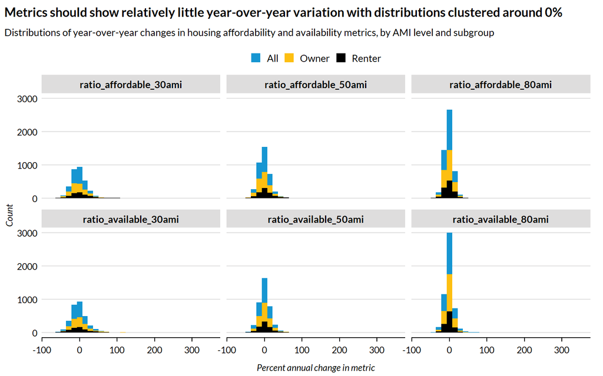

```r
housing_subgroups %>%
  select(-matches("quality")) %>%
  pivot_longer(cols = c(matches("ratio"), )) %>%
  pivot_wider(names_from = year, values_from = value, names_prefix = "value_") %>%
  mutate(percent_annual_change = (value_2022 - value_2021) / value_2021 * 100) %>%
  arrange(desc(percent_annual_change)) %>%
  ggplot() +
    geom_histogram(aes(x = percent_annual_change, fill = subgroup)) +
    facet_wrap(~ name) +
    urbnthemes::theme_urbn_print() +
  labs(
    x = "Percent annual change in metric",
    y = "Count",
    title = "Metrics should show relatively little year-over-year variation with distributions clustered around 0%",
    subtitle = "Distributions of year-over-year changes in housing affordability and availability metrics, by AMI level and subgroup")
```